# Garridos_SampleOutput

Charlene Garridos

04-12-22

# Problem Set 1

```r
You go to the store and buy x bags of carrots and y bananas.  Each bag of carrots costs $1.50 and each banana is $0.25.  You spend $6.50.  The total number of items you purchase is 11. How many bags of carrots did you buy?  How many bananas did you buy?
```

1. Write an equation with x and y.
2. Find the value of the following:
   1. x
   2. y

## Solution

Given the information, we have 2 equations. We know each bag of carrots is $1.50 and each banana is $0.25. We also know the total amount we spend is $6.50. So, we can write the equation

1.5x+0.25y=6.5

where x is the number of bags of carrots and y is the number of bananas.

We also know the total number of items we purchased is 11. We can write the equation as

x+y=11

where x is number of bags of carrots and y is the number of bananas.

To solve, we will solve for one variable in one equation and substitute it into the other equation. So,

x+y=11

y=11−x

Now, we can substitute the value of y into the first equation. We get,

1.5x+0.25(11−x)=6.5

We distribute.

1.5x+2.75−0.25x=6.5

We combine like terms.

1.25x+2.75=6.5

We solve for x by getting x alone.

1.25x+2.75−2.75=6.5−2.75

1.25x=3.75

x=3

Therefore, the number of bags of carrots we bought is 3. To find the number of bananas, we simply substitute x into the equation.

x+y=11

3+y=11

3+y−3=11−3

y=11−3

y=8

Therefore, the number of bananas we bought is 8.

So we bought 3 bags of carrots and 8 bananas.

Reference: https://www.varsitytutors.com/prealgebra-help/word-problems-with-two-unknowns

# Data Visualization

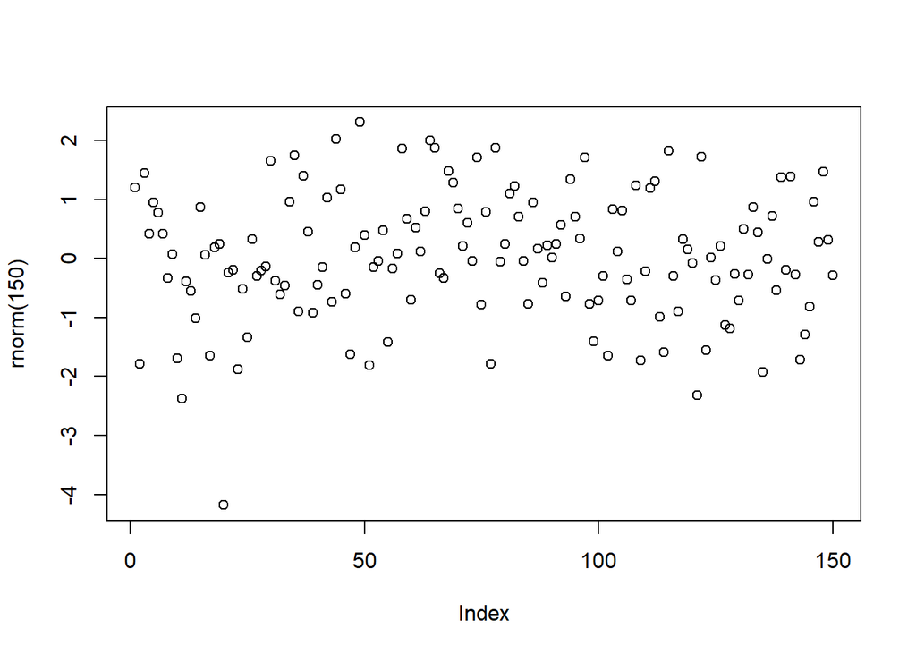

```r
plot(rnorm(150))
```

# Acknowledgement

I’d want to express gratitude to the speaker, Sir Cuenca, Sir Benitez as well as the facilitators and those who helped make this workshop possible. I sincerely appreciate your time, effort, and passion in educating us. Thank you so much for an excellent and amusing lecture po.